[figure not shown]

# STAT 650 - Midterm Project Guidelines

*Developed by Yoonsung Jung*

## 1. Guideline of Requirements

- Submit three files including .ipynb file, excel data file and .html file for your final .ipynb

## 2. Evaluation Criteria

Your project will be evaluated using the following criteria:

- Your raw dataset must contain at least 5 columns including at least 2 categorical and 3 quantitative variables (5 pts)
- Your raw dataset must include 100 rows of data or more. (5 pts)
- You must ask and answer at least 3 questions about the dataset. (10 + 20 pts = 30 pts)
- Your must run EDA approaches and include at least 4 or more visualizations (graphs and tables) (25 pts)
  - Each question must have at least one visualization
  - Your submission must include explanations using markdown cells, apart from the code.
- You must Follow the step-by-step guide to work on your project. (10 pts)
- You must do data processing and provide summary. reference (10 + 10 pts)
- Share your outcome (5 pts)
- Your work must not be plagiarized i.e. copy-pasted for somewhere else.

## 3. Step-by-step guide (10 pts)

### Step 1: Select a real-world dataset (5 + 5 pts)

- Find an interesting dataset.
- The data should be in MS Excel format, and should contain at least 5 columns and 100 rows or more.
- Download the dataset (**It must be submitted**).
- Add the data description and source information in Introduction section.

### Step 2: Ask questions (EDA Hypothesis) about data (10 pts)

- Express the reason that you are interested in the dataset in Introduction section.
- Ask at least 3 interesting questions about your dataset with simple reason why you are interested in.

### Step 3: Perform data preparation & cleaning (10 pts)

- Load the dataset into a data frame using Pandas
- Explore the number of rows & columns, ranges of values etc.
- Handle missing, incorrect and invalid data
- Perform any additional steps (parsing dates, creating additional columns, merging multiple dataset etc.)

### Step 4: Perform EDA & visualization (25 pts)

- Compute the descriptive statistics including the mean, sum, range and other interesting statistics for numeric columns
  - you can make some tables and graphs
- Explore distributions of numeric columns using visualzation approaches as histograms etc.
- Explore relationship between columns using numerical or graphical approaches as correlation, heatmap, scatter plots, bar charts etc.
- Make a note of interesting insights from the exploratory analysis.

### Step 5: Answer questions about the data (20 pts)

- Answer the questions either by computing the results using Numpy/Pandas or by plotting graphs using Matplotlib.
- Create new columns, merge multiple dataset and perform grouping/aggregation wherever necessary.
- Wherever you're using a library function from Pandas/Numpy/Matplotlib etc. explain briefly what it does.

### Step 6: Summarize project and References (10 pts)

- Write a summary of what you've learned from the analysis
- Include interesting insights and graphs from previous sections
- Share ideas for future work on the same topic using other relevant datasets
- make a list of references information related to this project.
- Share links to resources you found useful during your analysis

### Step 7: Submit and Share your work (5 pts)

- Submit your files (.ipynb, excel file, .html)
- Share your work at Discussion board with introduction and .html.

# Airline Passenger Satisfaction

*Developed by (Name: Rohan Dhadwal - 734002706)*

## 1. Introduction

- Write a short introduction/background about your data. (include information of data source )

**Dataset** - Airline Passenger Satisfaction

**Source** - https://www.kaggle.com/datasets/teejmahal20/airline-passenger-satisfaction

This dataset represents airline passenger satisfaction survey results that were collected to evaluate factors that influence passenger satisfaction or dissatisfaction. It includes various aspects of the travel experience, such as inflight services, online booking, and airport conveniences. Each passenger's satisfaction is rated based on multiple features, including flight distance, class, inflight wifi service, departure/arrival time convenience, ease of online booking, gate location, food and drink quality, online boarding, seat comfort, inflight entertainment, on-board service, legroom, baggage handling, check-in service, inflight service, cleanliness, and any departure or arrival delays, along with demographic information like age, gender, and customer loyalty. These features collectively offer a detailed view of the factors that contribute to overall passenger satisfaction.

The dataset originates from an airline survey and is designed to assess the correlation between passenger satisfaction and specific services provided during air travel. The satisfaction outcomes are categorized as "satisfied" or "neutral or dissatisfied." This offers valuable insight into which factors most strongly affect customer experience, helping airlines optimize their services.

**Columns** -

Gender: Gender of the passengers (Female, Male)

Customer Type: The customer type (Loyal customer, disloyal customer)

Age: The actual age of the passengers

Type of Travel: Purpose of the flight of the passengers (Personal Travel, Business Travel)

Class: Travel class in the plane of the passengers (Business, Eco, Eco Plus)

Flight distance: The flight distance of this journey

Inflight wifi service: Satisfaction level of the inflight wifi service (0:Not Applicable;1-5)

Departure/Arrival time convenient: Satisfaction level of Departure/Arrival time convenient

Ease of Online booking: Satisfaction level of online booking

Gate location: Satisfaction level of Gate location

Food and drink: Satisfaction level of Food and drink

Online boarding: Satisfaction level of online boarding

Seat comfort: Satisfaction level of Seat comfort

Inflight entertainment: Satisfaction level of inflight entertainment

On-board service: Satisfaction level of On-board service

Leg room service: Satisfaction level of Leg room service

Baggage handling: Satisfaction level of baggage handling

Check-in service: Satisfaction level of Check-in service

Inflight service: Satisfaction level of inflight service

Cleanliness: Satisfaction level of Cleanliness

Departure Delay in Minutes: Minutes delayed when departure

Arrival Delay in Minutes: Minutes delayed when Arrival

Satisfaction: Airline satisfaction level(Satisfaction, neutral or dissatisfaction)

- what is your research objective(s) and goal(s)

The objective of this project is to conduct comprehensive exploratory data analysis (EDA) to uncover the underlying patterns, distributions, and correlations within the airline passenger satisfaction dataset. By analyzing various aspects of the passenger journey, we aim to identify key factors that influence satisfaction and dissatisfaction levels. Ultimately, this analysis could be used to predict passenger satisfaction and suggest improvements to airline services. This will allow the airline to prioritize the factors that affect customer satisfaction and make informed decisions.

This exploration will serve as a foundation for further predictive modeling and customer experience optimization.

### 2. EDA Hypotheses (Ask you questions)

Having worked in the hospitality industry before, I was always curious about the airline department in my previous organization. This sparked a personal interest in exploring how airlines measure and improve customer satisfaction. I see this project as an opportunity to make an impact in the travel/airline industry by understanding the key drivers of passenger satisfaction and dissatisfaction.

**Key Research Questions:**

1. **What factors most strongly correlate with passenger satisfaction?** I am interested in identifying the most significant drivers of passenger satisfaction, such as inflight wifi service, seat comfort, or baggage handling, to understand what airlines should prioritize for improving the passenger experience.
2. **How does seat comfort influence overall satisfaction among passengers?** This question aims to explore the relationship between passengers' perceptions of seat comfort and their overall satisfaction. This can help inform airlines on potential improvements to seat design or legroom which is an important aspect.
3. **How does the satisfaction level vary by passenger age group?** Understanding how different age demographics perceive airline services can help tailor marketing strategies and service offerings, ensuring that airlines meet the diverse needs of their passengers.

These questions will guide my exploratory data analysis where I will aim to derive actionable insights for enhancing the airline customer experience. As I delve deeper into the dataset, I might also analyze additional factors or trends to uncover deeper insights and potential areas for improvement in airline operations and customer satisfaction strategies.

## 3. Data Analysis

### 3-1. Importing the libraries necessary for your EDA

```python
# Importing libraries for EDA
import numpy as np
import pandas as pd
import matplotlib.pyplot as plt
import seaborn as sns
from sklearn.preprocessing import LabelEncoder
from sklearn.preprocessing import StandardScaler
from sklearn.decomposition import PCA
```

### 3-2. Importing data

```python
# Importing data.csv using the pandas read_csv function
df = pd.read_csv('data.csv')

# df.head() displays the first five rows of the DataFrame 'df'
df.head()
```

|  | Unnamed: 0 | id | Gender | Customer Type | Age | Type of Travel | Class | Flight Distance | Inflight wifi service | Departure/Arrival time convenient | ... | Inflight entertainment | On-board service | Leg room service | Baggage handling | Checkin service | Inflight service | Cleanliness | Departure Delay in Minutes | Arrival Delay in Minutes | satisfaction |
| --- | --- | --- | --- | --- | --- | --- | --- | --- | --- | --- | --- | --- | --- | --- | --- | --- | --- | --- | --- | --- | --- |
| 0 | 0 | 19556 | Female | Loyal Customer | 52 | Business travel | Eco | 160 | 5 | 4 | ... | 5 | 5 | 5 | 5 | 2 | 5 | 5 | 50 | 44.0 | satisfied |
| 1 | 1 | 90035 | Female | Loyal Customer | 36 | Business travel | Business | 2863 | 1 | 1 | ... | 4 | 4 | 4 | 4 | 3 | 4 | 5 | 0 | 0.0 | satisfied |
| 2 | 2 | 12360 | Male | disloyal Customer | 20 | Business travel | Eco | 192 | 2 | 0 | ... | 2 | 4 | 1 | 3 | 2 | 2 | 2 | 0 | 0.0 | neutral or dissatisfied |
| 3 | 3 | 77959 | Male | Loyal Customer | 44 | Business travel | Business | 3377 | 0 | 0 | ... | 1 | 1 | 1 | 1 | 3 | 1 | 4 | 0 | 6.0 | satisfied |
| 4 | 4 | 36875 | Female | Loyal Customer | 49 | Business travel | Eco | 1182 | 2 | 3 | ... | 2 | 2 | 2 | 2 | 4 | 2 | 4 | 0 | 20.0 | satisfied |

5 rows × 25 columns

### 3-3. Review Data

```python
# 1. Check data dimension by using .shape

# df.shape returns a tuple representing the dimensions of the DataFrame 'df',
# where the first element is the number of rows (observations) and the second element is the number of columns (features)
df.shape
```

```
(25976, 25)
```

This means that we have 25 columns and 25,976 data entries for this dataset

```python
# 2. Check types of data by .info() ; .dtype

# df.info() provides a concise summary of the DataFrame, including the number of non-null entries, and the data types of each column
# It helps in understanding the structure of the dataset and identifying any potential issues with missing data
df.info()
```

```
<class 'pandas.core.frame.DataFrame'>
RangeIndex: 25976 entries, 0 to 25975
Data columns (total 25 columns):
 #   Column                             Non-Null Count  Dtype
---  ------                             --------------  -----
 0   Unnamed: 0                         25976 non-null  int64
 1   id                                 25976 non-null  int64
 2   Gender                             25976 non-null  object
 3   Customer Type                      25976 non-null  object
 4   Age                                25976 non-null  int64
 5   Type of Travel                     25976 non-null  object
 6   Class                              25976 non-null  object
 7   Flight Distance                    25976 non-null  int64
 8   Inflight wifi service              25976 non-null  int64
 9   Departure/Arrival time convenient  25976 non-null  int64
```

[output cut: 17 more lines]

```python
# 3. For quantitative variable, generate a table for the count, mean, standard deviation, minimum and maximum values and the quantities of the data

# The describe() function generates descriptive statistics of the DataFrame's numerical columns,
# including count, mean, standard deviation, minimum, maximum, and quartile values.
df.describe()
```

|  | Unnamed: 0 | id | Age | Flight Distance | Inflight wifi service | Departure/Arrival time convenient | Ease of Online booking | Gate location | Food and drink | Online boarding | Seat comfort | Inflight entertainment | On-board service | Leg room service | Baggage handling | Checkin service | Inflight service | Cleanliness | Departure Delay in Minutes | Arrival Delay in Minutes |
| --- | --- | --- | --- | --- | --- | --- | --- | --- | --- | --- | --- | --- | --- | --- | --- | --- | --- | --- | --- | --- |
| count | 25976.000000 | 25976.000000 | 25976.000000 | 25976.000000 | 25976.000000 | 25976.000000 | 25976.000000 | 25976.000000 | 25976.000000 | 25976.000000 | 25976.000000 | 25976.000000 | 25976.000000 | 25976.000000 | 25976.000000 | 25976.000000 | 25976.000000 | 25976.000000 | 25976.00000 | 25893.000000 |
| mean | 12987.500000 | 65005.657992 | 39.620958 | 1193.788459 | 2.724746 | 3.046812 | 2.756775 | 2.977094 | 3.215353 | 3.261665 | 3.449222 | 3.357753 | 3.385664 | 3.350169 | 3.633238 | 3.314175 | 3.649253 | 3.286226 | 14.30609 | 14.740857 |
| std | 7498.769632 | 37611.526647 | 15.135685 | 998.683999 | 1.335384 | 1.533371 | 1.412951 | 1.282133 | 1.331506 | 1.355536 | 1.320090 | 1.338299 | 1.282088 | 1.318862 | 1.176525 | 1.269332 | 1.180681 | 1.319330 | 37.42316 | 37.517539 |
| min | 0.000000 | 17.000000 | 7.000000 | 31.000000 | 0.000000 | 0.000000 | 0.000000 | 1.000000 | 0.000000 | 0.000000 | 1.000000 | 0.000000 | 0.000000 | 0.000000 | 1.000000 | 1.000000 | 0.000000 | 0.000000 | 0.00000 | 0.000000 |
| 25% | 6493.750000 | 32170.500000 | 27.000000 | 414.000000 | 2.000000 | 2.000000 | 2.000000 | 2.000000 | 2.000000 | 2.000000 | 2.000000 | 2.000000 | 2.000000 | 2.000000 | 3.000000 | 3.000000 | 3.000000 | 2.000000 | 0.00000 | 0.000000 |
| 50% | 12987.500000 | 65319.500000 | 40.000000 | 849.000000 | 3.000000 | 3.000000 | 3.000000 | 3.000000 | 3.000000 | 4.000000 | 4.000000 | 4.000000 | 4.000000 | 4.000000 | 4.000000 | 3.000000 | 4.000000 | 3.000000 | 0.00000 | 0.000000 |
| 75% | 19481.250000 | 97584.250000 | 51.000000 | 1744.000000 | 4.000000 | 4.000000 | 4.000000 | 4.000000 | 4.000000 | 4.000000 | 5.000000 | 4.000000 | 4.000000 | 4.000000 | 5.000000 | 4.000000 | 5.000000 | 4.000000 | 12.00000 | 13.000000 |
| max | 25975.000000 | 129877.000000 | 85.000000 | 4983.000000 | 5.000000 | 5.000000 | 5.000000 | 5.000000 | 5.000000 | 5.000000 | 5.000000 | 5.000000 | 5.000000 | 5.000000 | 5.000000 | 5.000000 | 5.000000 | 5.000000 | 1128.00000 | 1115.000000 |

### 3-4. Generate Sub-dataset

```python
# Setting the index of the dataframe
df.set_index('Unnamed: 0')

# Dropping irrelevant columns using the pandas drop function
df = df.drop(columns=['Unnamed: 0','id'])

# Displaying the dataframe
df.head()
```

|  | Gender | Customer Type | Age | Type of Travel | Class | Flight Distance | Inflight wifi service | Departure/Arrival time convenient | Ease of Online booking | Gate location | ... | Inflight entertainment | On-board service | Leg room service | Baggage handling | Checkin service | Inflight service | Cleanliness | Departure Delay in Minutes | Arrival Delay in Minutes | satisfaction |
| --- | --- | --- | --- | --- | --- | --- | --- | --- | --- | --- | --- | --- | --- | --- | --- | --- | --- | --- | --- | --- | --- |
| 0 | Female | Loyal Customer | 52 | Business travel | Eco | 160 | 5 | 4 | 3 | 4 | ... | 5 | 5 | 5 | 5 | 2 | 5 | 5 | 50 | 44.0 | satisfied |
| 1 | Female | Loyal Customer | 36 | Business travel | Business | 2863 | 1 | 1 | 3 | 1 | ... | 4 | 4 | 4 | 4 | 3 | 4 | 5 | 0 | 0.0 | satisfied |
| 2 | Male | disloyal Customer | 20 | Business travel | Eco | 192 | 2 | 0 | 2 | 4 | ... | 2 | 4 | 1 | 3 | 2 | 2 | 2 | 0 | 0.0 | neutral or dissatisfied |
| 3 | Male | Loyal Customer | 44 | Business travel | Business | 3377 | 0 | 0 | 0 | 2 | ... | 1 | 1 | 1 | 1 | 3 | 1 | 4 | 0 | 6.0 | satisfied |
| 4 | Female | Loyal Customer | 49 | Business travel | Eco | 1182 | 2 | 3 | 4 | 3 | ... | 2 | 2 | 2 | 2 | 4 | 2 | 4 | 0 | 20.0 | satisfied |

5 rows × 23 columns

```python
# Renaming columns to maintain consistency
df.rename(columns={
    'Customer Type': 'CustomerType',
    'Type of Travel': 'TravelType',
    'Flight Distance': 'FlightDistance',
    'Inflight wifi service': 'WifiService',
    'Departure/Arrival time convenient': 'DeptArrTimeConvenience',
    'Ease of Online booking': 'OnlineBookingEase',
    'Gate location': 'GateLocation',
    'Food and drink': 'FoodDrink',
    'Online boarding': 'OnlineBoarding',
    'Seat comfort': 'SeatComfort',
    'Inflight entertainment': 'InflightEntertainment',
    'On-board service': 'OnboardService',
    'Leg room service': 'LegroomService',
    'Baggage handling': 'BaggageHandling',
    'Checkin service': 'CheckinService',
    'Inflight service': 'InflightService',
    'Cleanliness': 'Cleanliness',
    'Departure Delay in Minutes': 'DepartureDelayMinutes',
    'Arrival Delay in Minutes': 'ArrivalDelayMinutes',
    'satisfaction': 'Satisfaction'
}, inplace=True)

# Displaying the dataframe with new column names
df.head()
```

|  | Gender | CustomerType | Age | TravelType | Class | FlightDistance | WifiService | DeptArrTimeConvenience | OnlineBookingEase | GateLocation | ... | InflightEntertainment | OnboardService | LegroomService | BaggageHandling | CheckinService | InflightService | Cleanliness | DepartureDelayMinutes | ArrivalDelayMinutes | Satisfaction |
| --- | --- | --- | --- | --- | --- | --- | --- | --- | --- | --- | --- | --- | --- | --- | --- | --- | --- | --- | --- | --- | --- |
| 0 | Female | Loyal Customer | 52 | Business travel | Eco | 160 | 5 | 4 | 3 | 4 | ... | 5 | 5 | 5 | 5 | 2 | 5 | 5 | 50 | 44.0 | satisfied |
| 1 | Female | Loyal Customer | 36 | Business travel | Business | 2863 | 1 | 1 | 3 | 1 | ... | 4 | 4 | 4 | 4 | 3 | 4 | 5 | 0 | 0.0 | satisfied |
| 2 | Male | disloyal Customer | 20 | Business travel | Eco | 192 | 2 | 0 | 2 | 4 | ... | 2 | 4 | 1 | 3 | 2 | 2 | 2 | 0 | 0.0 | neutral or dissatisfied |
| 3 | Male | Loyal Customer | 44 | Business travel | Business | 3377 | 0 | 0 | 0 | 2 | ... | 1 | 1 | 1 | 1 | 3 | 1 | 4 | 0 | 6.0 | satisfied |
| 4 | Female | Loyal Customer | 49 | Business travel | Eco | 1182 | 2 | 3 | 4 | 3 | ... | 2 | 2 | 2 | 2 | 4 | 2 | 4 | 0 | 20.0 | satisfied |

5 rows × 23 columns

```python
# Checking missing/null values using pandas isna() function
print('Missing values:\n',df.isna().sum())
```

```
Missing values:
 Gender                     0
CustomerType               0
Age                        0
TravelType                 0
Class                      0
FlightDistance             0
WifiService                0
DeptArrTimeConvenience     0
OnlineBookingEase          0
GateLocation               0
FoodDrink                  0
OnlineBoarding             0
SeatComfort                0
InflightEntertainment      0
OnboardService             0
LegroomService             0
BaggageHandling            0
CheckinService             0
InflightService            0
Cleanliness                0
DepartureDelayMinutes      0
ArrivalDelayMinutes       83
Satisfaction               0
dtype: int64
```

It is evident that ArrivalDelayMinutes has 83 missing values. We can handle it by dropping the rows corresponding to empty values.

```python
# Dropping rows with null values using the pandas dropna function
df.dropna(inplace=True)

# Checking missing values
print('Missing values:\n',df.isna().sum())
```

```
Missing values:
 Gender                    0
CustomerType              0
Age                       0
TravelType                0
Class                     0
FlightDistance            0
WifiService               0
DeptArrTimeConvenience    0
OnlineBookingEase         0
GateLocation              0
FoodDrink                 0
OnlineBoarding            0
SeatComfort               0
InflightEntertainment     0
OnboardService            0
LegroomService            0
BaggageHandling           0
CheckinService            0
InflightService           0
Cleanliness               0
DepartureDelayMinutes     0
ArrivalDelayMinutes       0
Satisfaction              0
dtype: int64
```

Rows with missing values successfully dropped

```python
# Checking for duplicated rows in the DataFrame
print("Number of duplicated rows:", df.duplicated().sum())
```

```
Number of duplicated rows: 0
```

### 3-5. Checking Outliers

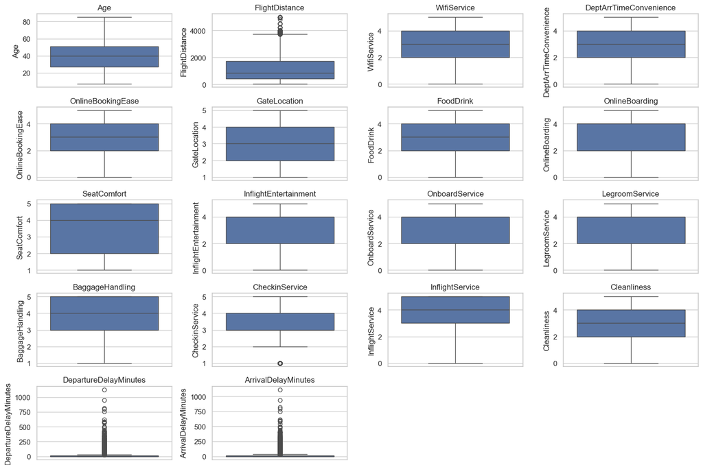

```python
# Visualizing outliers using boxplot

# visualization style
sns.set(style="whitegrid")

# Identifying quantitative columns
quantitative_cols = df.describe().columns

# Creating the plot
plt.figure(figsize=(15, 10))
num_cols = len(quantitative_cols)
rows = (num_cols // 4) + 1  # Calculate the number of rows needed

for i, col in enumerate(quantitative_cols):
    plt.subplot(rows, 4, i + 1)  # Adjusting the grid size dynamically
    sns.boxplot(y=df[col])
    plt.title(col)

# Show plot
plt.tight_layout()
plt.show()
```

The box plots here provide insights into the distribution and presence of outliers for each dataset column. Here's what can be interpreted about the outliers:

**FlightDistance:** There are several outliers on the higher end, indicating some flights have significantly longer distances than most.

**DepartureDelayMinutes** and **ArrivalDelayMinutes:** Both have numerous high-value outliers, suggesting that while most flights experience minimal delays, a few have very long delays.

**CheckinService:** There are multiple low-value (CheckinService=1) outliers, indicating an unusually poor check-in service experience

```python
# Outlier columns
outlier_columns = ['FlightDistance', 'DepartureDelayMinutes', 'ArrivalDelayMinutes', 'CheckinService']

# Function for calculating outliers
def calculate_outliers(column):
    Q1 = df[column].quantile(0.25)  # First quartile (25th percentile)
    Q3 = df[column].quantile(0.75)  # Third quartile (75th percentile)
    IQR = Q3 - Q1  # Interquartile range

    lower_bound = Q1 - 1.5 * IQR  # Lower bound
    upper_bound = Q3 + 1.5 * IQR  # Upper bound

    # Identifying outliers
    outliers = df[(df[column] < lower_bound) | (df[column] > upper_bound)]

    return len(outliers)

# Displaying number of outliers
for col in outlier_columns:
    count = calculate_outliers(col)
    print(f"Number of outliers in '{col}': {count}")
```

```
Number of outliers in 'FlightDistance': 580
Number of outliers in 'DepartureDelayMinutes': 3542
Number of outliers in 'ArrivalDelayMinutes': 3538
Number of outliers in 'CheckinService': 3206
```

### 3-6. Visualizing categorical column distribution

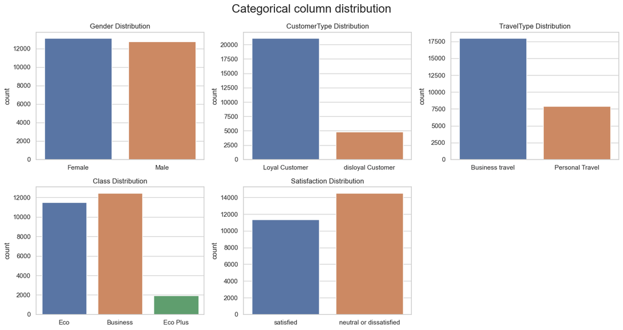

```python
# Identifying categorical columns
categorical_cols = ['Gender', 'CustomerType', 'TravelType', 'Class', 'Satisfaction']

# Setting the style of the plots
sns.set(style="whitegrid")

# Creating subplots with 5 plots, adjusting for rows and columns
fig, axes = plt.subplots(2, 3, figsize=(15, 8))
fig.suptitle("Categorical column distribution", fontsize=20)
axes = axes.flatten()  # Flatten for easy iteration

# Plotting each categorical variable
for i, col in enumerate(categorical_cols):
    sns.countplot(data=df, x=col, ax=axes[i], hue=col)
    axes[i].set_title(f'{col} Distribution')
    axes[i].tick_params(axis='x')
    axes[i].set_xlabel('')

# Removing extra subplot
fig.delaxes(axes[-1])

# Show plot
plt.tight_layout()
plt.show()
```

- **Gender Distribution:** The dataset has a nearly equal distribution of male and female participants.
- **CustomerType Distribution:** There are significantly more loyal customers compared to disloyal ones.
- **TravelType Distribution:** Business travel is more common than personal travel.
- **Class Distribution:** Most travelers are in the Business and Eco classes, with very few in Eco Plus.
- **Satisfaction Distribution:** More customers are neutral or dissatisfied compared to those who are satisfied.

### 3-7. Converting categorical columns to numerical values for EDA

```python
# LabelEncoder() is a function from scikit-learn that converts categorical string labels into numerical format
# This is useful for preparing categorical variables for machine learning models that require numerical input
# Instantiating LabelEncoder()
label_encoder = LabelEncoder()

# Creating a dictionary to store the mapping for each categorical column
label_mappings = {}

# Encoding categorical columns
for col in categorical_cols:
    df[col] = label_encoder.fit_transform(df[col])
    label_mappings[col] = dict(zip(label_encoder.classes_, range(len(label_encoder.classes_))))

# Printing the mappings
for col, mapping in label_mappings.items():
    print(f"{col} mapping: {mapping}")
```

```
Gender mapping: {'Female': 0, 'Male': 1}
CustomerType mapping: {'Loyal Customer': 0, 'disloyal Customer': 1}
TravelType mapping: {'Business travel': 0, 'Personal Travel': 1}
Class mapping: {'Business': 0, 'Eco': 1, 'Eco Plus': 2}
Satisfaction mapping: {'neutral or dissatisfied': 0, 'satisfied': 1}
```

```python
# Displaying DataFrame
df.head()
```

|  | Gender | CustomerType | Age | TravelType | Class | FlightDistance | WifiService | DeptArrTimeConvenience | OnlineBookingEase | GateLocation | ... | InflightEntertainment | OnboardService | LegroomService | BaggageHandling | CheckinService | InflightService | Cleanliness | DepartureDelayMinutes | ArrivalDelayMinutes | Satisfaction |
| --- | --- | --- | --- | --- | --- | --- | --- | --- | --- | --- | --- | --- | --- | --- | --- | --- | --- | --- | --- | --- | --- |
| 0 | 0 | 0 | 52 | 0 | 1 | 160 | 5 | 4 | 3 | 4 | ... | 5 | 5 | 5 | 5 | 2 | 5 | 5 | 50 | 44.0 | 1 |
| 1 | 0 | 0 | 36 | 0 | 0 | 2863 | 1 | 1 | 3 | 1 | ... | 4 | 4 | 4 | 4 | 3 | 4 | 5 | 0 | 0.0 | 1 |
| 2 | 1 | 1 | 20 | 0 | 1 | 192 | 2 | 0 | 2 | 4 | ... | 2 | 4 | 1 | 3 | 2 | 2 | 2 | 0 | 0.0 | 0 |
| 3 | 1 | 0 | 44 | 0 | 0 | 3377 | 0 | 0 | 0 | 2 | ... | 1 | 1 | 1 | 1 | 3 | 1 | 4 | 0 | 6.0 | 1 |
| 4 | 0 | 0 | 49 | 0 | 1 | 1182 | 2 | 3 | 4 | 3 | ... | 2 | 2 | 2 | 2 | 4 | 2 | 4 | 0 | 20.0 | 1 |

5 rows × 23 columns

## 4. EDA & Visualization

### 4-1. Univariate Analysis

#### Summary Statistics

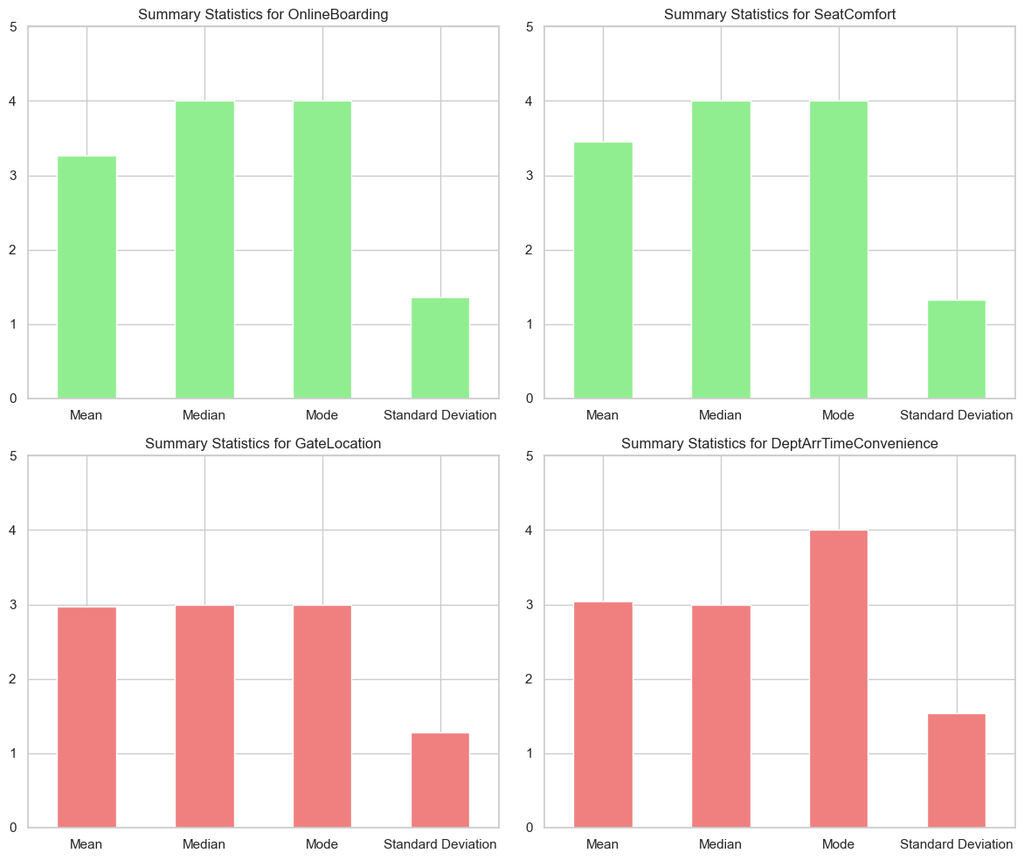

```python
# Features to analyze
features = ['OnlineBoarding', 'SeatComfort', 'GateLocation', 'DeptArrTimeConvenience']

# Calculating summary statistics for the features
summary_stats = df[features].agg(['mean', 'median', lambda x: x.mode()[0], 'std'])
summary_stats.index = ['Mean', 'Median', 'Mode', 'Standard Deviation']

# Transposing the summary statistics for easy iteration
summary_stats_T = summary_stats.T

# Create subplots for summary statistics
fig, axes = plt.subplots(2, 2, figsize=(12, 10))

# Defining colors
color_relevant = 'lightgreen'  # Color for OnlineBoarding and SeatComfort
color_non_relevant = 'lightcoral'  # Color for GateLocation and DeptArrTimeConvenience

# Plotting summary statistics for each feature in separate subplots
for ax, feature in zip(axes.flatten(), features):
    if feature in ['OnlineBoarding', 'SeatComfort']:
        summary_stats_T.loc[feature].plot(kind='bar', ax=ax, color=color_relevant)
    else:
        summary_stats_T.loc[feature].plot(kind='bar', ax=ax, color=color_non_relevant)

    ax.set_title(f'Summary Statistics for {feature}')
    ax.set_ylim(0,5)
    ax.tick_params(axis='x', rotation=0)

# Show plot
plt.tight_layout()
plt.show()
```

#### KDE for seat comfort

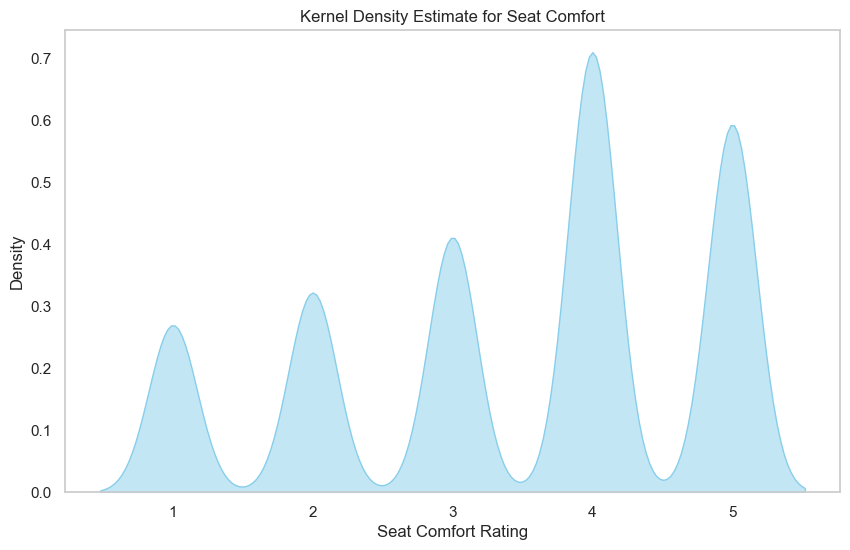

```python
# Creating a KDE plot for Seat Comfort
plt.figure(figsize=(10, 6))
sns.kdeplot(df['SeatComfort'], fill=True, color='skyblue', alpha=0.5)
plt.title('Kernel Density Estimate for Seat Comfort')
plt.xlabel('Seat Comfort Rating')
plt.ylabel('Density')
plt.xticks([1, 2, 3, 4, 5])
plt.grid()
plt.show()
```

The kernel density estimate for seat comfort ratings shows distinct peaks at each rating level, with a significant peak at rating 4. This suggests that most passengers rate their seat comfort as above average (mean=3.44), indicating general satisfaction with seating.

#### Histogram for Age & FlightDistance

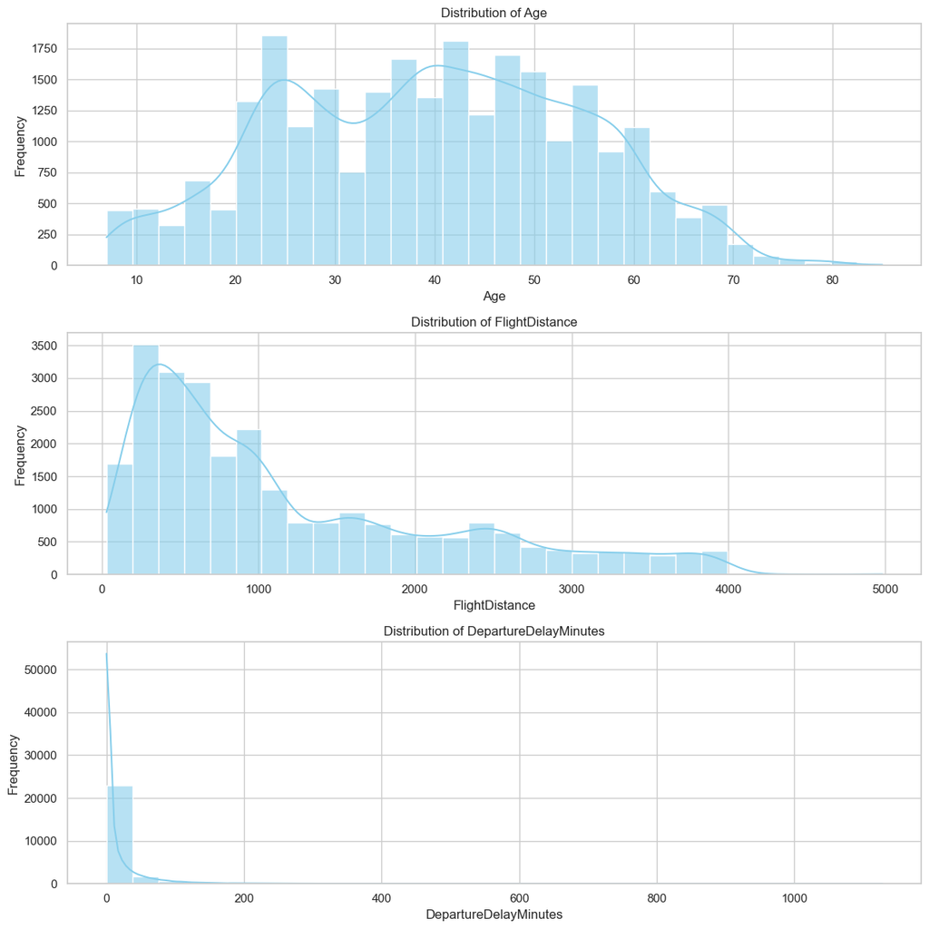

```python
# Features to analyze
features = ['Age', 'FlightDistance', 'DepartureDelayMinutes']

# Setting plot style
sns.set(style='whitegrid')

# Creating subplots for the distributions
fig, axes = plt.subplots(3, 1, figsize=(12, 12))

# Plotting for each feature
for ax, feature in zip(axes.flatten(), features):

    sns.histplot(df[feature], ax=ax, kde=True, color='skyblue', bins=30, alpha=0.6)
    ax.set_title(f'Distribution of {feature}')
    ax.set_xlabel(feature)
    ax.set_ylabel('Frequency')

# Showing plots
plt.tight_layout()
plt.show()
```

The first histogram shows the distribution of **age**, which appears to be roughly normal with a slight right skew. Most individuals are between 20 and 50 years old, with peaks around 20 and 40. There is a gradual decline in frequency as age increases beyond 50, with very few individuals over 70.

The second histogram displays the distribution of **flight distances**, which is heavily right-skewed. Most flights are short, with a distance under 1000 units, and the frequency decreases sharply as distance increases. There are occasional longer flights, but they are much less common.

### 4-2. Bivariate Analysis

#### Analysis between Age and Flight Distance

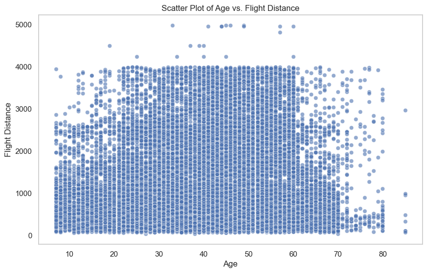

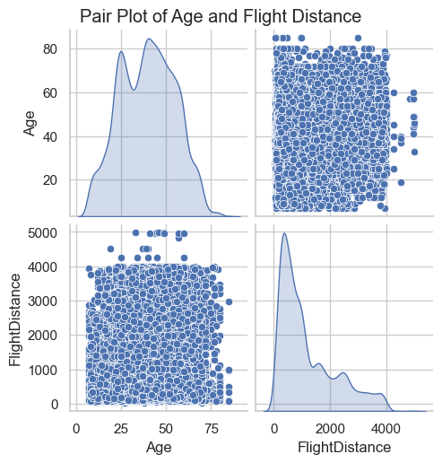

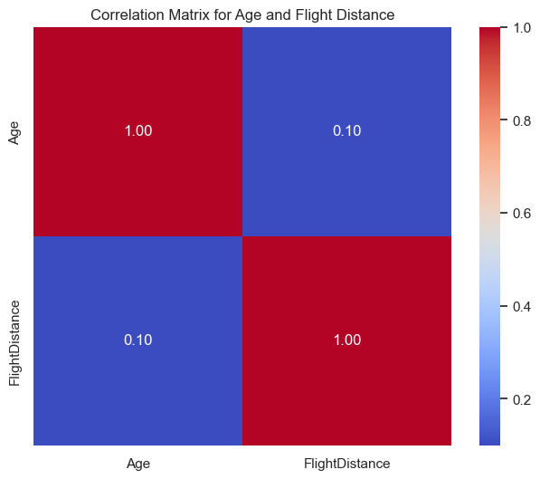

```python
# 1. Scatter Plot for Age vs. Flight Distance
plt.figure(figsize=(10, 6))
sns.scatterplot(data=df, x='Age', y='FlightDistance', alpha=0.6)
plt.title('Scatter Plot of Age vs. Flight Distance')
plt.xlabel('Age')
plt.ylabel('Flight Distance')
plt.grid()
plt.show()

# 2. Pair Plot for Age and Flight Distance
plt.figure(figsize=(10, 6))
sns.pairplot(df[['Age', 'FlightDistance']], diag_kind='kde', markers='o')
plt.suptitle('Pair Plot of Age and Flight Distance', y=1.02)
plt.show()

# 3. Correlation Matrix
correlation_matrix = df[['Age', 'FlightDistance']].corr()

plt.figure(figsize=(8, 6))
sns.heatmap(correlation_matrix, annot=True, fmt='.2f', cmap='coolwarm', square=True)
plt.title('Correlation Matrix for Age and Flight Distance')
plt.show()
```

The visualizations provide insights into the relationships between age and flight distance. The scatter plot shows a broad distribution of flight distances across different ages, indicating no strong correlation between these two variables. The pair plot further illustrates this by showing a dispersed pattern with no clear trend. The correlation matrix confirms these observations, showing low correlation coefficients: 0.10 between age and flight distance.

These low values suggest that age & flight distance are largely independent of each other in this dataset. This might imply that factors such as age might not significantly influence customer preferences for flight distance, suggesting that other variables might be more impactful in understanding customer behavior or satisfaction.

#### Analysis between Age Groups and Passenger Satisfaction

```
  AgeGroup  Satisfaction
0     0-18      0.181152
1    19-30      0.359614
2    31-45      0.476414
3    46-60      0.576843
4    61-75      0.264310
5      76+      0.372727
```

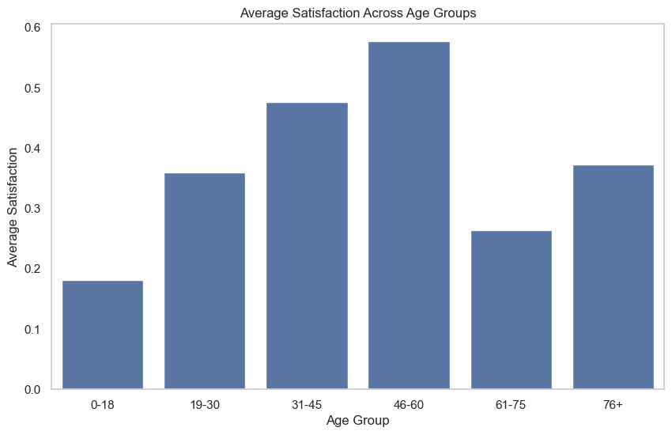

```python
# Creating age groups
# np.inf represents positive infinity, allowing for an open-ended upper limit for the last age group
bins = [0, 18, 30, 45, 60, 75, np.inf]
labels = ['0-18', '19-30', '31-45', '46-60', '61-75', '76+']
df['AgeGroup'] = pd.cut(df['Age'], bins=bins, labels=labels, right=False)

# Calculating average satisfaction by age group
average_satisfaction_by_age = df.groupby('AgeGroup',observed=True)['Satisfaction'].mean().reset_index()
print(average_satisfaction_by_age)

# Plotting
plt.figure(figsize=(10, 6))
sns.barplot(data=average_satisfaction_by_age, x='AgeGroup', y='Satisfaction')
plt.title('Average Satisfaction Across Age Groups')
plt.xlabel('Age Group')
plt.ylabel('Average Satisfaction')
plt.grid(axis='y')
plt.show()
```

The bar chart shows average satisfaction across age groups, highlighting that passengers aged 46-60 report the highest satisfaction, while the youngest group (0-18) reports the lowest passenger satisfaction.

```python
# Dropping AgeGroup column as it is not required after the analysis above
df.drop(columns=['AgeGroup'],inplace=True)
```

### 4-3. Multivariate Analysis

#### Analyzing correlation between Age, SeatComfort, & InflightEntertainment

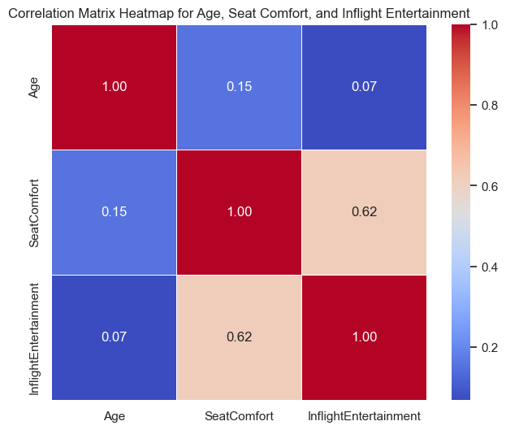

```python
# Selecting features to compare
features = ['Age', 'SeatComfort', 'InflightEntertainment']

# Calculating the correlation matrix for selected features
correlation_matrix = df[features].corr()

# Setting up the figure
plt.figure(figsize=(8, 6))

# Creating a heatmap to visualize the correlation matrix
sns.heatmap(correlation_matrix, annot=True, fmt='.2f', cmap='coolwarm', square=True, linewidths=0.5)
plt.title('Correlation Matrix Heatmap for Age, Seat Comfort, and Inflight Entertainment')
plt.show()
```

The correlation matrix highlights the relationships between age, seat comfort, and inflight entertainment. The matrix shows a low correlation between age and both seat comfort (0.15), and inflight entertainment (0.07), suggesting that age has little impact on how passengers perceive these aspects. However, there is a moderate correlation (0.62) between seat comfort and inflight entertainment, indicating that improvements in one might positively influence perceptions of the other.

#### PCA (Principal Component Analysis)

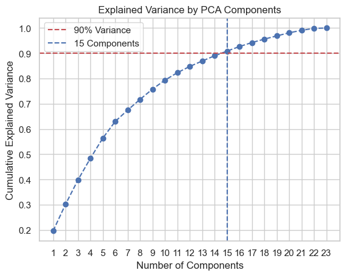

```
15 components explain 90% variance
```

```python
# Standardizing the data as PCA requires scaling
df_standardized = StandardScaler().fit_transform(df)

# Applying PCA
pca = PCA()
pca_result = pca.fit_transform(df_standardized)

# np.cumsum computes the cumulative sum of the elements along a specified axis
# It returns an array where each element at index i is the sum of the elements from the original array up to index i
# Calculating cumulative explained variance
cumulative_variance = np.cumsum(pca.explained_variance_ratio_)

# np.argmax returns the indices of the maximum values along a specified axis
# It can be used to find the index of the first occurrence of the maximum value in an array
# number of components to explain 90% variance
n_components = np.argmax(cumulative_variance >= 0.90) + 1

# Plotting
plt.plot(range(1, len(cumulative_variance) + 1), cumulative_variance, marker='o', linestyle='--')
plt.axhline(y=0.90, color='r', linestyle='--', label='90% Variance')
plt.axvline(x=n_components, color='b', linestyle='--', label=f'{n_components} Components')
plt.title('Explained Variance by PCA Components')
plt.xlabel('Number of Components')
plt.ylabel('Cumulative Explained Variance')
plt.xticks(range(1, len(cumulative_variance) + 1))  # Adjust x-ticks to start from 1
plt.legend()
plt.show()

# Printing number of relevant components
print(f'{n_components} components explain 90% variance')
```

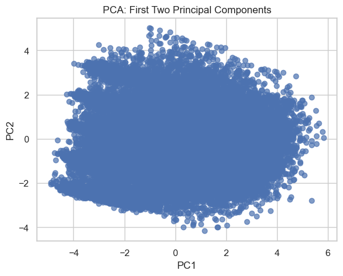

```python
# Applying PCA with the chosen number of components
pca_final = PCA(n_components=n_components)
pca_data = pca_final.fit_transform(df_standardized)

# Step 7: Visualize the first two components
plt.scatter(pca_data[:, 0], pca_data[:, 1], alpha=0.7)
plt.title('PCA: First Two Principal Components')
plt.xlabel('PC1')
plt.ylabel('PC2')
plt.grid(True)
plt.show()
```

The scatter plot of the first two principal components (PC1 and PC2 shows how data points are distributed in the reduced two-dimensional space. The dense clustering around the center suggests that these two components capture some structure in the data, but given that only two components are plotted, they might not fully represent the complexity of the dataset.

Together, these visualizations highlight PCA's effectiveness in reducing dimensionality while retaining most of the data's variability.

#### Analyzing correlation of all features with passenger satisfaction

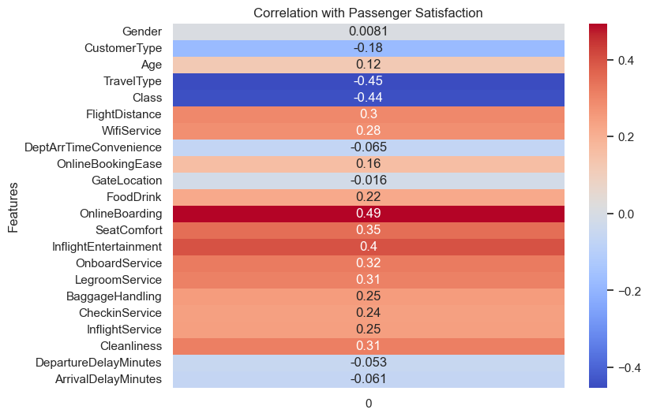

```python
# Correlation matrix focusing on satisfaction
corr_satisfaction = df.corr()['Satisfaction'].drop('Satisfaction')

# Creating a heatmap for correlation
plt.figure(figsize=(8, 6))
sns.heatmap(corr_satisfaction.values.reshape(-1, 1), annot=True, cmap='coolwarm', yticklabels=corr_satisfaction.index)
plt.title('Correlation with Passenger Satisfaction')
plt.ylabel('Features')
plt.show()
```

Conversely, factors like flight delays (both departure and arrival) have negative correlations with satisfaction, meaning that shorter delays lead to higher satisfaction. While delays can frustrate passengers, reduced delays positively influence satisfaction.

Additionally, the minimal impact of gate location and gender suggests these factors are not major drivers of satisfaction compared to service quality, comfort, and less delays.

## 5. Conclusion

### Answer the questions

**What factors most strongly correlate with passenger satisfaction?**

The heatmap of correlations with passenger satisfaction shows that online boarding (0.49), inflight entertainment (0.4) & seat comfort (0.35) have the highest positive correlations. This indicates that these factors are significant drivers of passenger satisfaction. Airlines should prioritize enhancing these areas to improve the overall passenger experience.

The scatter plot and pair plot indicate a broad distribution of flight distances across different ages, with a low correlation coefficient of 0.10, suggesting no strong direct relationship between age and flight distance preferences. Similarly, the correlation matrix shows that flight distance has a moderate positive correlation (0.3) with passenger satisfaction. This implies that while longer flights might slightly increase satisfaction due to additional services or amenities offered, age does not significantly modify this relationship. Therefore, airlines should focus on enhancing services for all passengers on longer flights rather than targeting specific age groups.

**How does passenger satisfaction vary across different demographic age groups?**

The average satisfaction levels across different age groups indicate a positive trend with increasing age, peaking at the 46-60 age group, which has a mean satisfaction score of 0.57. This is illustrated in the bar plot, where satisfaction levels rise from 0.181 in the 0-18 group to 0.576 in the 46-60 group. However, there is a notable decrease in satisfaction for the 61-75 age group (0.26), followed by a slight increase for those aged 76+ (0.37). From the correlation matrix, age shows a positive correlation of 0.12 with passenger satisfaction, indicating that older passengers tend to report higher satisfaction levels. So airlines can prioritize younger passengers to enhance their experiences.

## 6. Summary

Through comprehensive analysis of various factors influencing airline passenger satisfaction, several key insights were gathered.Firstly, the box plots provided insights into the distribution and presence of outliers in critical areas such as flight distance and flight delays. The analysis of outliers in check-in service ratings and delays highlighted opportunities for operational improvements in these areas to ensure consistency.

The histograms provide valuable insights into the distribution of key variables like age and flight distance. The age distribution is roughly normal, with a slight right skew, indicating that most passengers fall between the ages of 20 and 50, with a notable decline in frequency after 50 years. This skew toward younger travelers suggests that airlines catering to younger demographics could have a more significant impact on overall satisfaction.

The flight distance histogram, which is heavily right-skewed, indicates that most flights are shorter, with few long-haul flights. This data aligns with the positive correlation (0.3) between flight distance and satisfaction and suggests that passengers on longer flights tend to be more satisfied, possibly due to the enhanced amenities provided on such flights. However, since the majority of flights are short, airlines should ensure that even short-haul passengers have access to quality services that can improve their satisfaction levels.

The kernel density estimate (KDE) plot for seat comfort shows a significant peak at rating 4, suggesting that most passengers rate their seat comfort as above average. This further emphasizes the importance of seating comfort, especially as it moderately correlates (0.35) with overall satisfaction. Airlines should continue investing in comfortable seating as it plays a significant role in shaping passengers' experiences.

The bivariate analysis revealed that there is no strong correlation between age and flight distance, as indicated by a low correlation coefficient of 0.10. This suggests that age does not significantly influence passengers' preferences for flight distance. Visualizations like scatter plots and pair plots further confirmed this finding, showing a broad and dispersed distribution of flight distances across different age groups without any clear trend. This indicates that flight distance is largely independent of age, implying that other factors, such as service quality or flight purpose, may have a stronger impact on passengers' preferences.

The analysis through the bar plot also explored how passenger satisfaction varies across different demographic age groups. The average satisfaction levels increased with age, peaking at the 46-60 age group with a mean score of 0.57. Interestingly, satisfaction levels dropped for the 61-75 age group (0.26) before slightly rising for those aged 76 and above (0.37). This suggests that while older passengers tend to report higher satisfaction levels, there are instances that need addressing particularly for the senior demographic age groups. Therefore, airlines may benefit from targeted strategies that enhance the travel experience for younger passengers, potentially leading to improved loyalty and satisfaction.

Additionally, the plot for cumulative explained variance by Principal Component Analysis indicated that 15 components are sufficient to explain 90% of the dataset's variance, highlighting the potential for dimensionality reduction without significant information loss. This could streamline future analyses and facilitate more targeted inquiries into specific aspects of passenger satisfaction.

Finally, the correlation matrix revealed that online boarding (0.49), inflight entertainment (0.4), and seat comfort (0.35) have the strongest positive correlation with passenger satisfaction. This indicates that airlines should prioritize enhancements in these areas, as they play a significant role in improving the overall passenger satisfaction experience. Conversely, factors such as flight delays, both departure and arrival, have a negative correlation with satisfaction, meaning that shorter delays generally lead to higher levels of passenger contentment. This highlights the importance of operational efficiency in airlines to mitigate delays and their adverse effects on customer satisfaction.

## Limitations

**Limited Variability in Features:** Many columns contained distinct integer values (1-5), which restricted the ability to analyze trends effectively through scatter plots. The lack of continuous data made it challenging to identify clear relationships between features.

**Outliers in Data:** The presence of outliers especially in flight distance could skew the analysis and affect the mean values, potentially leading to misleading insights.

**Unscaled Data:** The original dataset is not standardized which posed challenges when comparing variables directly. When features have different ranges or units, it becomes difficult to assess their relative importance or understand their relationships with one another.

## Future Work

**Outlier Removal:** The current analysis highlighted outliers, particularly in variables like checkin service, flight distance, departure delay, and arrival delay. Removing or handling these outliers using techniques like Z-scores, IQR-based filtering, or robust scaling could improve the accuracy and reliability of the analysis. Outlier removal can provide a clearer picture of trends and relationships in the data by reducing noise caused by extreme values.

**Dimensionality Reduction:** The PCA analysis revealed that 15 components can explain 90% of the variance in the data, suggesting significant potential for dimensionality reduction. By focusing on these components, we can simplify the dataset while retaining the most important information, reducing computational complexity, and improving model performance. This can be particularly useful in reducing multicollinearity in subsequent modeling efforts.

**Clustering Analysis:** Passenger satisfaction could be further analyzed using unsupervised learning techniques like K-means clustering. By grouping passengers into clusters based on factors like age and preferences for services, we can better understand distinct passenger segments. This would help identify specific groups that require focused interventions such as improving the experience of younger passengers or those on shorter flights.

**Classification Model for Predicting Passenger Satisfaction:** Given the correlations identified between various features (such as inflight entertainment, seat comfort, and online boarding) and passenger satisfaction, we could develop a classification model to predict passenger satisfaction. Models such as Logistic Regression, Decision Trees, Random Forests could be trained on the dataset to predict whether a passenger will be satisfied or dissatisfied based on their flight experience. This could provide actionable insights for airlines to preemptively improve services for passengers likely to be dissatisfied.

## References

Pandas: https://pandas.pydata.org/docs/

Numpy: https://numpy.org/doc/

Matplotlib: https://matplotlib.org/stable/index.html

Seaborn: https://seaborn.pydata.org/

Sklearn: https://scikit-learn.org/0.21/documentation.html